# Summary of Statistical Analysis

#### ** This notebook only covers analysis of models that include all networks. **

#### Prepare environment

```r
#Hidden output
rm(list = ls()) #clear/ all
library(ggplot2)
library(palmerpenguins)
library(dplyr)
library(ggstatsplot)
library(tidyr)
library("ggpubr")
library(rstatix)
library(tidyverse)
library(lme4)
library(nlme)
library(ggpubr)
library(lmerTest)
library(afex)
library(wesanderson)
library(emmeans)
library(stringr)
library(ggh4x)
library(psycho)
library(tidyverse)
library(DT)
```

#### Prepare data

```r
disp_data <- read.csv("new_delat_vals.csv")

nets = c('VN', 'SMN', 'DAN', 'SN', 'LN', 'FPN', 'DMN')
disp_data$Network <- factor(disp_data$Network ,levels=nets)

#color map python
color_map= c('#781286', '#4682B4','#00760E', '#BE3AFA',
                'palegreen' , '#E69422','#CD3E4E')
```

##### Take a look at the data frame

```r
head(disp_data, n=10)
```

```
##    X Subject Session Network Centroid_Shift Delta_Dispersion
## 1  0       1       1      VN    0.003549704       1.65585606
## 2  1       2       1      VN    0.021311752      -0.27296377
## 3  2       3       1      VN    0.023589005      -1.94456018
## 4  3       4       1      VN    0.010532395       0.04866156
## 5  4       5       1      VN    0.007620352      -0.39441124
## 6  5       6       1      VN    0.039839876      -1.63299761
## 7  6       7       1      VN    0.018233792      -1.74843678
## 8  7       8       1      VN    0.019917127      -1.31636430
## 9  8       9       1      VN    0.012944752       0.95639572
## 10 9      10       1      VN    0.045721656      -3.13493846
##    Delta_Dispersion_New
## 1           0.138645750
## 2          -0.016487064
## 3          -0.152151052
## 4           0.003738054
## 5          -0.026573919
## 6          -0.128523188
## 7          -0.119959180
## 8          -0.090138068
## 9           0.086734656
## 10         -0.231949228
```

##### Order levels of the Network variable

```r
disp_data$Session<-as.factor(disp_data$Session)
disp_data$Network<-as.factor(disp_data$Network)
```

##### Remove additional index columns

```r
drop_cols = c("X")
disp_data = disp_data[,!(names(disp_data) %in% drop_cols)]
```

##### Take a look at the data frame

```r
head(disp_data, n=10)
```

```
##    Subject Session Network Centroid_Shift Delta_Dispersion Delta_Dispersion_New
## 1        1       1      VN    0.003549704       1.65585606          0.138645750
## 2        2       1      VN    0.021311752      -0.27296377         -0.016487064
## 3        3       1      VN    0.023589005      -1.94456018         -0.152151052
## 4        4       1      VN    0.010532395       0.04866156          0.003738054
## 5        5       1      VN    0.007620352      -0.39441124         -0.026573919
## 6        6       1      VN    0.039839876      -1.63299761         -0.128523188
## 7        7       1      VN    0.018233792      -1.74843678         -0.119959180
## 8        8       1      VN    0.019917127      -1.31636430         -0.090138068
## 9        9       1      VN    0.012944752       0.95639572          0.086734656
## 10      10       1      VN    0.045721656      -3.13493846         -0.231949228
```

# Analysis of dispersion measures

## The new proportional dispersion value

The new dispersion value is calculated as follows:

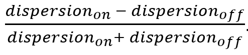

### Plotting the proportional dispersion value

```r
max_disp = round(max(disp_data$Delta_Dispersion_New), digits=1) + 0.1
min_disp = round(min(disp_data$Delta_Dispersion_New), digits=1) - 0.1
sub_title_col = 'black'
#Plot dd new val
vp_dd<- ggplot(data=disp_data, aes(x=Network, y=Delta_Dispersion_New, fill=Network)) +
    geom_violin(position=position_dodge(), alpha=0.5, inherit.aes = TRUE)+
    geom_dotplot(binaxis= "y",stackdir = "center",dotsize = 0.1,fill = 1,
                 binwidth=0.02)+
    stat_summary(fun = "mean",geom = "crossbar", width = 0.6,
                 colour = "black")+
    geom_hline(yintercept = 0, lty  =2, colour="black")+
    scale_fill_manual(values = color_map) +
    guides(fill = "none")+
    scale_x_discrete("Network")+
    scale_y_continuous(name= "Dispersion On-Off/Dispersion On+Off",
                       breaks = seq(min_disp, max_disp, 0.1))+
    theme_light()+
    ggtitle("Dispersion On-Off/Dispersion On+Off\n")+
    theme(plot.title = element_text(hjust = 0.5, size=18, face="bold"),
          legend.title = element_text(size=16),
          legend.text = element_text(size=16),
          axis.text=element_text(size=14),
          axis.title=element_text(size=16,face="bold"),
          strip.text = element_text(
          size = 14, color =sub_title_col, face =  "bold"))+
    facet_wrap("Session", labeller = as_labeller(c(
      "1" = "Session 1 - Unilateral","2" = "Session 2 - Bilateral",
      "3"= "Session 3 - Sham")))
  #save dd
  vp_dd
```

[figure not shown]

### Linear mixed model for the new proportional dispersion value

```r
Model<-lmer(Delta_Dispersion_New ~ Network*Session +(1|Subject),data = disp_data)
summary(Model)
```

```
## Linear mixed model fit by REML. t-tests use Satterthwaite's method [
## lmerModLmerTest]
## Formula: Delta_Dispersion_New ~ Network * Session + (1 | Subject)
##    Data: disp_data
##
## REML criterion at convergence: -494.6
##
## Scaled residuals:
##     Min      1Q  Median      3Q     Max
## -3.2499 -0.6397  0.0107  0.6182  2.8744
##
## Random effects:
##  Groups   Name        Variance  Std.Dev.
##  Subject  (Intercept) 0.0001432 0.01197
##  Residual             0.0076869 0.08768
## Number of obs: 294, groups:  Subject, 14
##
## Fixed effects:
##                       Estimate Std. Error         df t value Pr(>|t|)
## (Intercept)         -1.723e-02  2.365e-02  2.712e+02  -0.729    0.467
## NetworkSMN           2.387e-03  3.314e-02  2.600e+02   0.072    0.943
## NetworkDAN           1.766e-02  3.314e-02  2.600e+02   0.533    0.594
## NetworkSN           -9.666e-03  3.314e-02  2.600e+02  -0.292    0.771
## NetworkLN           -1.026e-02  3.314e-02  2.600e+02  -0.310    0.757
## NetworkFPN          -3.442e-03  3.314e-02  2.600e+02  -0.104    0.917
## NetworkDMN          -6.716e-03  3.314e-02  2.600e+02  -0.203    0.840
## Session2            -2.514e-02  3.314e-02  2.600e+02  -0.759    0.449
## Session3             1.181e-04  3.314e-02  2.600e+02   0.004    0.997
## NetworkSMN:Session2 -4.611e-02  4.686e-02  2.600e+02  -0.984    0.326
## NetworkDAN:Session2  1.142e-02  4.686e-02  2.600e+02   0.244    0.808
## NetworkSN:Session2   3.968e-02  4.686e-02  2.600e+02   0.847    0.398
## NetworkLN:Session2   7.145e-02  4.686e-02  2.600e+02   1.525    0.129
## NetworkFPN:Session2  6.808e-02  4.686e-02  2.600e+02   1.453    0.148
## NetworkDMN:Session2  5.410e-02  4.686e-02  2.600e+02   1.154    0.249
## NetworkSMN:Session3  3.966e-02  4.686e-02  2.600e+02   0.846    0.398
## NetworkDAN:Session3  5.010e-04  4.686e-02  2.600e+02   0.011    0.991
## NetworkSN:Session3   1.941e-02  4.686e-02  2.600e+02   0.414    0.679
## NetworkLN:Session3   9.657e-03  4.686e-02  2.600e+02   0.206    0.837
## NetworkFPN:Session3  1.554e-02  4.686e-02  2.600e+02   0.332    0.740
## NetworkDMN:Session3 -1.236e-02  4.686e-02  2.600e+02  -0.264    0.792
```

```
##
## Correlation matrix not shown by default, as p = 21 > 12.
## Use print(x, correlation=TRUE)  or
##     vcov(x)        if you need it
```

```r
anova(Model)
```

```
## Type III Analysis of Variance Table with Satterthwaite's method
##                   Sum Sq   Mean Sq NumDF DenDF F value Pr(>F)
## Network         0.024262 0.0040437     6   260  0.5261 0.7883
## Session         0.005623 0.0028114     2   260  0.3657 0.6940
## Network:Session 0.136071 0.0113393    12   260  1.4751 0.1334
```

### Tukey contrasts of the new proportional dispersion value

```r
emmeans(Model,pairwise~Network)
```

```
## NOTE: Results may be misleading due to involvement in interactions
```

```
## $emmeans
##  Network   emmean     SE  df lower.CL upper.CL
##  VN      -0.02557 0.0139 190  -0.0530  0.00185
##  SMN     -0.02533 0.0139 190  -0.0528  0.00209
##  DAN     -0.00393 0.0139 190  -0.0314  0.02349
##  SN      -0.01554 0.0139 190  -0.0430  0.01188
##  LN      -0.00879 0.0139 190  -0.0362  0.01863
##  FPN     -0.00114 0.0139 190  -0.0286  0.02628
##  DMN     -0.01837 0.0139 190  -0.0458  0.00905
##
## Results are averaged over the levels of: Session
## Degrees-of-freedom method: kenward-roger
## Confidence level used: 0.95
##
## $contrasts
##  contrast   estimate     SE  df t.ratio p.value
##  VN - SMN  -0.000237 0.0191 260  -0.012  1.0000
##  VN - DAN  -0.021640 0.0191 260  -1.131  0.9180
##  VN - SN   -0.010030 0.0191 260  -0.524  0.9985
##  VN - LN   -0.016778 0.0191 260  -0.877  0.9757
##  VN - FPN  -0.024432 0.0191 260  -1.277  0.8620
##  VN - DMN  -0.007198 0.0191 260  -0.376  0.9998
##  SMN - DAN -0.021403 0.0191 260  -1.119  0.9220
##  SMN - SN  -0.009794 0.0191 260  -0.512  0.9987
##  SMN - LN  -0.016541 0.0191 260  -0.865  0.9774
##  SMN - FPN -0.024195 0.0191 260  -1.265  0.8674
##  SMN - DMN -0.006961 0.0191 260  -0.364  0.9998
##  DAN - SN   0.011609 0.0191 260   0.607  0.9966
##  DAN - LN   0.004862 0.0191 260   0.254  1.0000
##  DAN - FPN -0.002792 0.0191 260  -0.146  1.0000
##  DAN - DMN  0.014442 0.0191 260   0.755  0.9888
##  SN - LN   -0.006747 0.0191 260  -0.353  0.9998
##  SN - FPN  -0.014401 0.0191 260  -0.753  0.9890
##  SN - DMN   0.002833 0.0191 260   0.148  1.0000
##  LN - FPN  -0.007654 0.0191 260  -0.400  0.9997
##  LN - DMN   0.009580 0.0191 260   0.501  0.9988
##  FPN - DMN  0.017234 0.0191 260   0.901  0.9722
##
## Results are averaged over the levels of: Session
## Degrees-of-freedom method: kenward-roger
## P value adjustment: tukey method for comparing a family of 7 estimates
```

```r
emmeans(Model,pairwise~Session)
```

```
## NOTE: Results may be misleading due to involvement in interactions
```

```
## $emmeans
##  Session  emmean      SE df lower.CL upper.CL
##  1       -0.0187 0.00942 70  -0.0374 0.000118
##  2       -0.0154 0.00942 70  -0.0342 0.003354
##  3       -0.0082 0.00942 70  -0.0270 0.010580
##
## Results are averaged over the levels of: Network
## Degrees-of-freedom method: kenward-roger
## Confidence level used: 0.95
##
## $contrasts
##  contrast            estimate     SE  df t.ratio p.value
##  Session1 - Session2 -0.00324 0.0125 260  -0.258  0.9639
##  Session1 - Session3 -0.01046 0.0125 260  -0.835  0.6815
##  Session2 - Session3 -0.00723 0.0125 260  -0.577  0.8326
##
## Results are averaged over the levels of: Network
## Degrees-of-freedom method: kenward-roger
## P value adjustment: tukey method for comparing a family of 3 estimates
```

#### -> In the model “Delta_Dispersion_New ~ Network*Session +(1|Subject)” No Variable is significant

#### -> In the model “Delta_Dispersion_New ~ Network*Session +(1|Subject)” No pairwise **Network** contrast is significant

#### -> In the model “Delta_Dispersion_New ~ Network*Session +(1|Subject)” No pairwise **Session** contrast is significant

## The original dispersion difference value

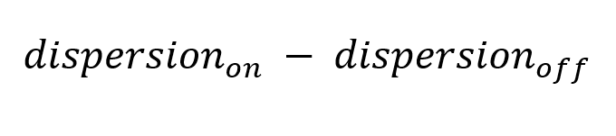

### Plotting the dispersion difference value

```r
#Plot dd old val
max_disp = round(max(disp_data$Delta_Dispersion), digits=0) + 1
min_disp = round(min(disp_data$Delta_Dispersion), digits=0) - 1

  vp_dd<- ggplot(data=disp_data, aes(x=Network, y=Delta_Dispersion, fill=Network)) +
    geom_violin(position=position_dodge(), alpha=0.5, inherit.aes = TRUE)+
    geom_dotplot(binaxis= "y",stackdir = "center",dotsize = 0.2,fill = 1,
                 binwidth=0.5)+
    stat_summary(fun = "mean",geom = "crossbar", width = 0.6,
                 colour = "black")+
    geom_hline(yintercept = 0, lty  =2, colour="black")+
    scale_fill_manual(values = color_map) +
    guides(fill = "none")+
    scale_x_discrete("Network")+
    scale_y_continuous(name= "Dispersion On-Off", breaks = seq(min_disp, max_disp, 1))+
    theme_light()+
    ggtitle("Dispersion On - Dispersion Off \n")+
    theme(plot.title = element_text(hjust = 0.5, size=18, face="bold"),
          legend.title = element_text(size=16),
          legend.text = element_text(size=16),
          axis.text=element_text(size=14),
          axis.title=element_text(size=16,face="bold"),
          strip.text = element_text(
            size = 14, color =sub_title_col, face =  "bold"))+
    facet_wrap("Session", labeller = as_labeller(c(
      "1" = "Session 1 - Unilateral","2" = "Session 2 - Bilateral",
      "3"= "Session 3 - Sham")))
  vp_dd
```

[figure not shown]

### Linear mixed model for Delta_Dispersion

```r
Model<-lmer(Delta_Dispersion ~ Network*Session +(1|Subject),data = disp_data)
summary(Model)
```

```
## Linear mixed model fit by REML. t-tests use Satterthwaite's method [
## lmerModLmerTest]
## Formula: Delta_Dispersion ~ Network * Session + (1 | Subject)
##    Data: disp_data
##
## REML criterion at convergence: 1039.1
##
## Scaled residuals:
##     Min      1Q  Median      3Q     Max
## -3.1582 -0.4456  0.0017  0.5309  4.8931
##
## Random effects:
##  Groups   Name        Variance Std.Dev.
##  Subject  (Intercept) 0.03173  0.1781
##  Residual             2.12190  1.4567
## Number of obs: 294, groups:  Subject, 14
##
## Fixed effects:
##                      Estimate Std. Error        df t value Pr(>|t|)
## (Intercept)          -0.27812    0.39221 271.81981  -0.709    0.479
## NetworkSMN            0.06986    0.55057 260.00000   0.127    0.899
## NetworkDAN            0.29084    0.55057 260.00000   0.528    0.598
## NetworkSN            -0.06198    0.55057 260.00000  -0.113    0.910
## NetworkLN             0.10492    0.55057 260.00000   0.191    0.849
## NetworkFPN           -0.08987    0.55057 260.00000  -0.163    0.870
## NetworkDMN           -0.47624    0.55057 260.00000  -0.865    0.388
## Session2             -0.31752    0.55057 260.00000  -0.577    0.565
## Session3             -0.03261    0.55057 260.00000  -0.059    0.953
## NetworkSMN:Session2  -0.87361    0.77863 260.00000  -1.122    0.263
## NetworkDAN:Session2   0.08459    0.77863 260.00000   0.109    0.914
## NetworkSN:Session2    0.50569    0.77863 260.00000   0.649    0.517
## NetworkLN:Session2    0.61241    0.77863 260.00000   0.787    0.432
## NetworkFPN:Session2   1.03135    0.77863 260.00000   1.325    0.186
## NetworkDMN:Session2   1.22791    0.77863 260.00000   1.577    0.116
## NetworkSMN:Session3   0.63320    0.77863 260.00000   0.813    0.417
## NetworkDAN:Session3   0.03791    0.77863 260.00000   0.049    0.961
## NetworkSN:Session3    0.27159    0.77863 260.00000   0.349    0.728
## NetworkLN:Session3    0.09170    0.77863 260.00000   0.118    0.906
## NetworkFPN:Session3   0.22221    0.77863 260.00000   0.285    0.776
## NetworkDMN:Session3  -0.31879    0.77863 260.00000  -0.409    0.683
```

```
##
## Correlation matrix not shown by default, as p = 21 > 12.
## Use print(x, correlation=TRUE)  or
##     vcov(x)        if you need it
```

```r
anova(Model)
```

```
## Type III Analysis of Variance Table with Satterthwaite's method
##                 Sum Sq Mean Sq NumDF DenDF F value Pr(>F)
## Network         10.723  1.7872     6   260  0.8422 0.5383
## Session          0.504  0.2518     2   260  0.1187 0.8881
## Network:Session 40.982  3.4151    12   260  1.6095 0.0889 .
## ---
## Signif. codes:  0 '***' 0.001 '**' 0.01 '*' 0.05 '.' 0.1 ' ' 1
```

#### -> In the model “Delta_Dispersion~ Network*Session +(1|Subject)” No Variable is significant but the interaction is close

### Tukey contrasts of Delta_Dispersion

```r
emmeans(Model,pairwise~Network)
```

```
## NOTE: Results may be misleading due to involvement in interactions
```

```
## $emmeans
##  Network  emmean   SE  df lower.CL upper.CL
##  VN      -0.3948 0.23 197   -0.848   0.0583
##  SMN     -0.4051 0.23 197   -0.858   0.0480
##  DAN     -0.0632 0.23 197   -0.516   0.3899
##  SN      -0.1977 0.23 197   -0.651   0.2554
##  LN      -0.0552 0.23 197   -0.508   0.3979
##  FPN     -0.0668 0.23 197   -0.520   0.3863
##  DMN     -0.5680 0.23 197   -1.021  -0.1149
##
## Results are averaged over the levels of: Session
## Degrees-of-freedom method: kenward-roger
## Confidence level used: 0.95
##
## $contrasts
##  contrast  estimate    SE  df t.ratio p.value
##  VN - SMN   0.01027 0.318 260   0.032  1.0000
##  VN - DAN  -0.33167 0.318 260  -1.043  0.9433
##  VN - SN   -0.19711 0.318 260  -0.620  0.9961
##  VN - LN   -0.33963 0.318 260  -1.068  0.9367
##  VN - FPN  -0.32799 0.318 260  -1.032  0.9462
##  VN - DMN   0.17320 0.318 260   0.545  0.9981
##  SMN - DAN -0.34194 0.318 260  -1.076  0.9347
##  SMN - SN  -0.20738 0.318 260  -0.652  0.9949
##  SMN - LN  -0.34990 0.318 260  -1.101  0.9275
##  SMN - FPN -0.33826 0.318 260  -1.064  0.9379
##  SMN - DMN  0.16293 0.318 260   0.513  0.9987
##  DAN - SN   0.13456 0.318 260   0.423  0.9996
##  DAN - LN  -0.00795 0.318 260  -0.025  1.0000
##  DAN - FPN  0.00369 0.318 260   0.012  1.0000
##  DAN - DMN  0.50487 0.318 260   1.588  0.6900
##  SN - LN   -0.14251 0.318 260  -0.448  0.9994
##  SN - FPN  -0.13087 0.318 260  -0.412  0.9996
##  SN - DMN   0.37031 0.318 260   1.165  0.9066
##  LN - FPN   0.01164 0.318 260   0.037  1.0000
##  LN - DMN   0.51282 0.318 260   1.613  0.6739
##  FPN - DMN  0.50118 0.318 260   1.577  0.6974
##
## Results are averaged over the levels of: Session
## Degrees-of-freedom method: kenward-roger
## P value adjustment: tukey method for comparing a family of 7 estimates
```

```r
emmeans(Model,pairwise~Session)
```

```
## NOTE: Results may be misleading due to involvement in interactions
```

```
## $emmeans
##  Session emmean    SE   df lower.CL upper.CL
##  1       -0.301 0.155 74.1   -0.609  0.00683
##  2       -0.249 0.155 74.1   -0.557  0.05907
##  3       -0.200 0.155 74.1   -0.508  0.10819
##
## Results are averaged over the levels of: Network
## Degrees-of-freedom method: kenward-roger
## Confidence level used: 0.95
##
## $contrasts
##  contrast            estimate    SE  df t.ratio p.value
##  Session1 - Session2  -0.0522 0.208 260  -0.251  0.9659
##  Session1 - Session3  -0.1014 0.208 260  -0.487  0.8775
##  Session2 - Session3  -0.0491 0.208 260  -0.236  0.9698
##
## Results are averaged over the levels of: Network
## Degrees-of-freedom method: kenward-roger
## P value adjustment: tukey method for comparing a family of 3 estimates
```

#### -> In the model “Delta_Dispersion~ Network*Session +(1|Subject)” No pairwise **Network** contrast is significant

#### -> In the model “Delta_Dispersion ~ Network*Session +(1|Subject)” No pairwise **Session** contrast is significant

# Analysis of centroid shifts’ measures

### Plotting centroid shifts in all sessions

```r
max_shift = round(max(disp_data$Centroid_Shift), digits=1) + 0.01
min_shift = round(min(disp_data$Centroid_Shift), digits=1) - 0.01
vp_dc<- ggplot(data=disp_data, aes(x=Network, y=Centroid_Shift, fill=Network)) +
    geom_violin(position=position_dodge(), alpha=0.5, inherit.aes = TRUE)+
    geom_dotplot(binaxis= "y",stackdir = "center",dotsize = 0.3,fill = 1,
                 binwidth=0.0015, aes (fill = Network))+
    stat_summary(fun = "mean",geom = "crossbar",
                 width = 0.6, colour = "black")+
    scale_fill_manual(values = color_map) +
    guides(fill = "none")+
    scale_x_discrete("Network")+
    scale_y_continuous(name= "Euclidean displacment",
                       breaks = seq(min_shift, max_shift, 0.005))+
    ggtitle("Centroid Displacement \n")+
    theme_bw()+
    theme(plot.title = element_text(hjust = 0.5, size=18, face="bold"),
          legend.title = element_text(size=16),
          legend.text = element_text(size=16),
          axis.text=element_text(size=14),
          axis.title=element_text(size=16,face="bold"),
          strip.text = element_text(
            size = 14, color =sub_title_col, face =  "bold"))+
    facet_wrap("Session", labeller = as_labeller(c(
      "1" = "Session 1 - Unilateral","2" = "Session 2 - Bilateral",
      "3"= "Session 3 - Sham")))

  #save dc
  vp_dc
```

[figure not shown]

### Linear mixed model for centroid shifts

```r
Model<-lmer(Centroid_Shift ~ Network*Session +(1|Subject),data = disp_data)
summary(Model)
```

```
## Linear mixed model fit by REML. t-tests use Satterthwaite's method [
## lmerModLmerTest]
## Formula: Centroid_Shift ~ Network * Session + (1 | Subject)
##    Data: disp_data
##
## REML criterion at convergence: -1780
##
## Scaled residuals:
##     Min      1Q  Median      3Q     Max
## -2.3798 -0.6249 -0.1349  0.4881  3.8344
##
## Random effects:
##  Groups   Name        Variance  Std.Dev.
##  Subject  (Intercept) 3.022e-06 0.001738
##  Residual             6.826e-05 0.008262
## Number of obs: 294, groups:  Subject, 14
##
## Fixed effects:
##                       Estimate Std. Error         df t value Pr(>|t|)
## (Intercept)          2.369e-02  2.256e-03  2.635e+02  10.499  < 2e-16 ***
## NetworkSMN          -6.303e-03  3.123e-03  2.600e+02  -2.018 0.044576 *
## NetworkDAN          -6.126e-03  3.123e-03  2.600e+02  -1.962 0.050834 .
## NetworkSN           -1.027e-02  3.123e-03  2.600e+02  -3.287 0.001150 **
## NetworkLN           -1.128e-02  3.123e-03  2.600e+02  -3.613 0.000363 ***
## NetworkFPN          -1.189e-02  3.123e-03  2.600e+02  -3.809 0.000174 ***
## NetworkDMN          -1.104e-02  3.123e-03  2.600e+02  -3.536 0.000481 ***
## Session2            -8.671e-03  3.123e-03  2.600e+02  -2.777 0.005890 **
## Session3            -1.069e-03  3.123e-03  2.600e+02  -0.342 0.732465
## NetworkSMN:Session2  7.287e-03  4.416e-03  2.600e+02   1.650 0.100140
## NetworkDAN:Session2  7.797e-03  4.416e-03  2.600e+02   1.766 0.078641 .
## NetworkSN:Session2   7.704e-03  4.416e-03  2.600e+02   1.745 0.082231 .
## NetworkLN:Session2   1.155e-02  4.416e-03  2.600e+02   2.616 0.009406 **
## NetworkFPN:Session2  1.017e-02  4.416e-03  2.600e+02   2.303 0.022061 *
## NetworkDMN:Session2  6.630e-03  4.416e-03  2.600e+02   1.501 0.134457
## NetworkSMN:Session3  1.792e-03  4.416e-03  2.600e+02   0.406 0.685234
## NetworkDAN:Session3  2.870e-03  4.416e-03  2.600e+02   0.650 0.516391
## NetworkSN:Session3   1.729e-03  4.416e-03  2.600e+02   0.392 0.695737
## NetworkLN:Session3   3.249e-03  4.416e-03  2.600e+02   0.736 0.462587
## NetworkFPN:Session3  6.236e-04  4.416e-03  2.600e+02   0.141 0.887808
## NetworkDMN:Session3 -2.505e-03  4.416e-03  2.600e+02  -0.567 0.571082
## ---
## Signif. codes:  0 '***' 0.001 '**' 0.01 '*' 0.05 '.' 0.1 ' ' 1
```

```
##
## Correlation matrix not shown by default, as p = 21 > 12.
## Use print(x, correlation=TRUE)  or
##     vcov(x)        if you need it
```

```r
anova(Model)
```

```
## Type III Analysis of Variance Table with Satterthwaite's method
##                     Sum Sq    Mean Sq NumDF DenDF F value    Pr(>F)
## Network         0.00302693 0.00050449     6   260  7.3912 2.577e-07 ***
## Session         0.00012530 0.00006265     2   260  0.9179    0.4007
## Network:Session 0.00078587 0.00006549    12   260  0.9595    0.4882
## ---
## Signif. codes:  0 '***' 0.001 '**' 0.01 '*' 0.05 '.' 0.1 ' ' 1
```

#### -> In the model “Centroid_Shift~ Network*Session +(1|Subject)” **Network** is a significant var

```r
emmeans(Model,pairwise~Network)
```

```
## NOTE: Results may be misleading due to involvement in interactions
```

```
## $emmeans
##  Network emmean      SE  df lower.CL upper.CL
##  VN      0.0204 0.00136 148  0.01776   0.0231
##  SMN     0.0172 0.00136 148  0.01449   0.0198
##  DAN     0.0179 0.00136 148  0.01519   0.0206
##  SN      0.0133 0.00136 148  0.01064   0.0160
##  LN      0.0141 0.00136 148  0.01141   0.0168
##  FPN     0.0121 0.00136 148  0.00947   0.0148
##  DMN     0.0108 0.00136 148  0.00810   0.0135
##
## Results are averaged over the levels of: Session
## Degrees-of-freedom method: kenward-roger
## Confidence level used: 0.95
##
## $contrasts
##  contrast   estimate     SE  df t.ratio p.value
##  VN - SMN   0.003276 0.0018 260   1.817  0.5375
##  VN - DAN   0.002571 0.0018 260   1.426  0.7873
##  VN - SN    0.007121 0.0018 260   3.950  0.0019
##  VN - LN    0.006348 0.0018 260   3.521  0.0091
##  VN - FPN   0.008295 0.0018 260   4.601  0.0001
##  VN - DMN   0.009666 0.0018 260   5.361  <.0001
##  SMN - DAN -0.000706 0.0018 260  -0.391  0.9997
##  SMN - SN   0.003845 0.0018 260   2.132  0.3368
##  SMN - LN   0.003071 0.0018 260   1.704  0.6143
##  SMN - FPN  0.005018 0.0018 260   2.784  0.0829
##  SMN - DMN  0.006389 0.0018 260   3.544  0.0084
##  DAN - SN   0.004550 0.0018 260   2.524  0.1551
##  DAN - LN   0.003777 0.0018 260   2.095  0.3588
##  DAN - FPN  0.005724 0.0018 260   3.175  0.0276
##  DAN - DMN  0.007095 0.0018 260   3.935  0.0020
##  SN - LN   -0.000773 0.0018 260  -0.429  0.9995
##  SN - FPN   0.001174 0.0018 260   0.651  0.9949
##  SN - DMN   0.002545 0.0018 260   1.411  0.7954
##  LN - FPN   0.001947 0.0018 260   1.080  0.9335
##  LN - DMN   0.003318 0.0018 260   1.840  0.5220
##  FPN - DMN  0.001371 0.0018 260   0.760  0.9884
##
## Results are averaged over the levels of: Session
## Degrees-of-freedom method: kenward-roger
## P value adjustment: tukey method for comparing a family of 7 estimates
```

```r
emmeans(Model,pairwise~Session)
```

```
## NOTE: Results may be misleading due to involvement in interactions
```

```
## $emmeans
##  Session emmean       SE   df lower.CL upper.CL
##  1       0.0156 0.000955 51.2   0.0136   0.0175
##  2       0.0142 0.000955 51.2   0.0123   0.0161
##  3       0.0156 0.000955 51.2   0.0137   0.0175
##
## Results are averaged over the levels of: Network
## Degrees-of-freedom method: kenward-roger
## Confidence level used: 0.95
##
## $contrasts
##  contrast             estimate      SE  df t.ratio p.value
##  Session1 - Session2  1.36e-03 0.00118 260   1.156  0.4805
##  Session1 - Session3 -3.97e-05 0.00118 260  -0.034  0.9994
##  Session2 - Session3 -1.40e-03 0.00118 260  -1.190  0.4603
##
## Results are averaged over the levels of: Network
## Degrees-of-freedom method: kenward-roger
## P value adjustment: tukey method for comparing a family of 3 estimates
```

#### -> In the model “Centroid_Shift ~ Network*Session +(1|Subject)” All CLs are positive -> all centoirds are shifted and != zero

#### the following pairwise **Network** contrast are significant

```
DAN - DMN, DAN - FPN, DMN - SMN,  DMN - VN, FPN - VN, LN - VN, SN - VN
```